# ANCOVA

Análise de Covariância  
Análise de Dados Ambientais

Luiz Diego Vidal Santos

## Roteiro da Aula

- 1 O que é ANCOVA?
- 2 Quando usar a ANCOVA?
- 3 Lógica — Removendo o ruído da covariável
- 4 Pressupostos específicos
- 5 Exemplo prático — Erosão e Cobertura
- 6 ANCOVA vs. ANOVA: quando preferir cada uma?

**Objetivo:** Compreender a ANCOVA como extensão da ANOVA que **controla estatisticamente** o efeito de variáveis contínuas intervenientes (covariáveis), aumentando a precisão da comparação entre grupos.

# 1 — O QUE É ANCOVA?

## Análise de Covariância

**Definição**

A **ANCOVA** (*Analysis of Covariance*) combina ANOVA e regressão linear. Ela compara médias de grupos enquanto **controla** o efeito de uma ou mais variáveis contínuas — as **covariáveis**.

**Estrutura mínima**

| Componente | Tipo | Exemplo |
| --- | --- | --- |
| VI (Fator) | Categórica | Tipo de manejo (3 níveis) |
| VD | Contínua | Perda de solo (t/ha) |
| **Covariável** | **Contínua** | Precipitação (mm) |

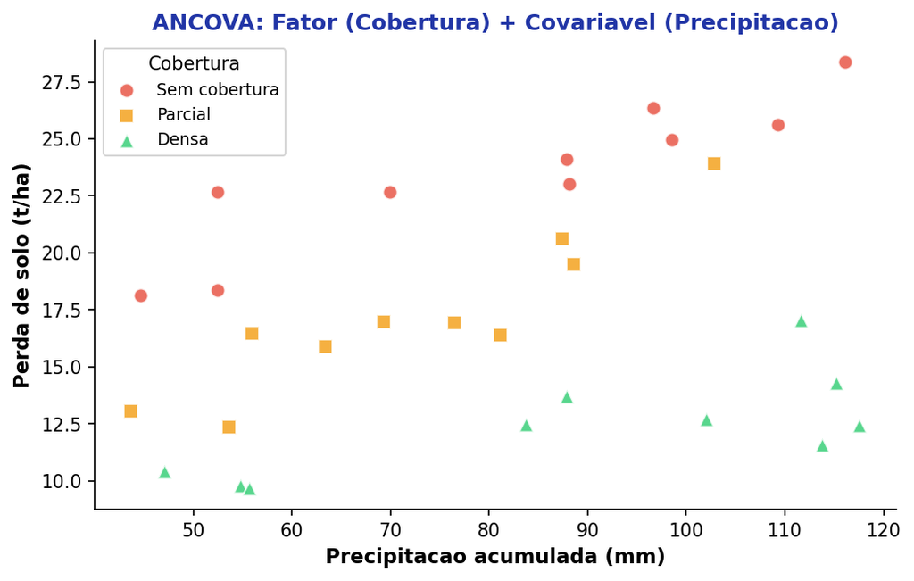

## Por que controlar covariáveis?

Imagine que você quer comparar a erosão entre 3 tipos de cobertura vegetal, **mas** a precipitação variou entre as parcelas:

**Sem ANCOVA:** a diferença entre os grupos pode ser devida à cobertura *ou* à precipitação — impossível separar.

**Com ANCOVA:** o efeito da precipitação é **removido estatisticamente**, e a comparação entre coberturas é feita como se todas as parcelas tivessem recebido a mesma chuva.

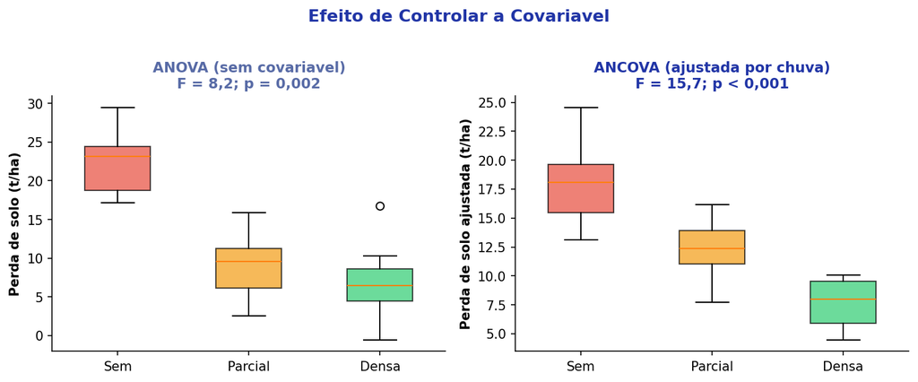

A ANCOVA **reduz a variância do erro** (SQ_Erro), aumentando o poder do teste F — ou seja, mais chance de detectar diferenças reais entre os grupos.

# 2 — QUANDO USAR A ANCOVA?

## Situações ideais para ANCOVA

**Use ANCOVA quando:**

- Há uma variável contínua que **influencia** a VD mas **não é o foco** da pesquisa
- Os grupos diferem em uma variável de confusão que não pôde ser controlada experimentalmente
- Deseja-se **aumentar o poder** reduzindo a variância residual

**Exemplos em Ciências Ambientais**

| VI (Fator) | VD | Covariável |
| --- | --- | --- |
| Tipo de manejo | Perda de solo | Precipitação |
| Espécie de gramínea | Biomassa | Declividade |
| Técnica de revegetação | Cobertura (%) | Umidade inicial do solo |
| Tipo de geotêxtil | Retenção de sedimento | Vazão de escoamento |

A ANCOVA é especialmente útil em **estudos de campo** (ciências ambientais, agronomia), onde variáveis como precipitação, declividade e tipo de solo variam entre parcelas e não podem ser completamente igualadas pelo delineamento.

# 3 — A LÓGICA DA ANCOVA

## Removendo o ruído da covariável

```
flowchart TD
    A["Variância Total\n(SQ Total)"]:::root --> B["Variância Explicada\npela Covariável"]:::node
    A --> C["Variância Restante"]:::node
    C --> D["Efeito do Fator\n(SQ Ajustada)"]:::result
    C --> E["Erro Residual\n(SQ Erro)"]:::leaf

    classDef root fill:#2135A6,color:#fff,font-weight:bold,stroke:#27368C
    classDef node fill:#C5CEE8,color:#0D0D0D,stroke:#586BA6
    classDef leaf fill:#586BA6,color:#fff,stroke:#27368C
    classDef result fill:#27368C,color:#fff,font-weight:bold,stroke:#2135A6
```

**Passo a passo conceitual:**

1. A covariável “absorve” parte da variância total
2. A variância restante é então decomposta em efeito do fator e erro
3. O SQ_Erro é **menor** que na ANOVA convencional → F maior → mais poder

**Tabela ANCOVA**

| Fonte | SQ | gl | QM | F |
| --- | --- | --- | --- | --- |
| Covariável | SQ_Cov | 1 | QM_Cov | QM_Cov / QM_E |
| Fator | SQ_Fator(adj) | k − 1 | QM_F | QM_F / QM_E |
| Erro | SQ_E | N − k − 1 | QM_E | — |

## Médias Ajustadas

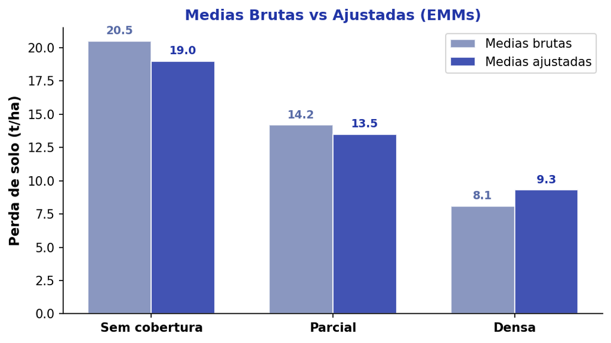

**Médias marginais estimadas** (EMMs)

A ANCOVA produz **médias ajustadas** — o valor esperado da VD para cada grupo quando a covariável é fixada em sua **média geral**.

São essas médias ajustadas que devem ser comparadas nos testes post-hoc, não as médias brutas.

As médias ajustadas podem ser **muito diferentes** das médias brutas, especialmente quando os grupos diferem na covariável. Essa diferença é a “correção” da ANCOVA.

# 4 — PRESSUPOSTOS

## Pressupostos Específicos da ANCOVA

Além dos pressupostos da ANOVA (normalidade, homocedasticidade, independência):

| Pressuposto | Teste | O que verificar |
| --- | --- | --- |
| **Linearidade** | Dispersão VD × Cov | Relação linear em cada grupo |
| **Homogeneidade de inclinações** | Interação Fator × Cov | As retas devem ser **paralelas** |
| **Covariável independente do fator** | ANOVA da covariável | Covariável não deve diferir entre grupos |

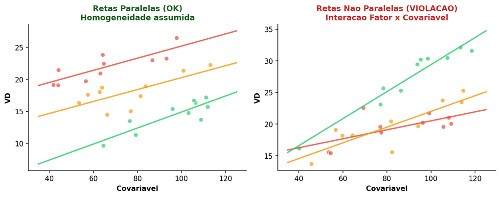

O pressuposto mais crítico é a **homogeneidade das inclinações de regressão** — se as retas não forem paralelas (interação significativa), a ANCOVA não é válida.

# 5 — EXEMPLO PRÁTICO

## Erosão e Cobertura Vegetal com Covariável

**Delineamento**

- **Fator:** Tipo de cobertura (Sem, Parcial, Densa)
- **VD:** Perda de solo (t/ha)
- **Covariável:** Precipitação acumulada (mm)
- **n = 10** por grupo → N = 30

**Resultados**

| Fonte | F | p-valor |
| --- | --- | --- |
| Precipitação (Cov) | 28,4 | < 0,001 |
| Cobertura (adj) | 15,7 | < 0,001 |
| Erro | — | — |

Sem a covariável (ANOVA simples): F = 8,2; p = 0,002

Com a covariável (ANCOVA): **F = 15,7; p < 0,001** → poder aumentou!

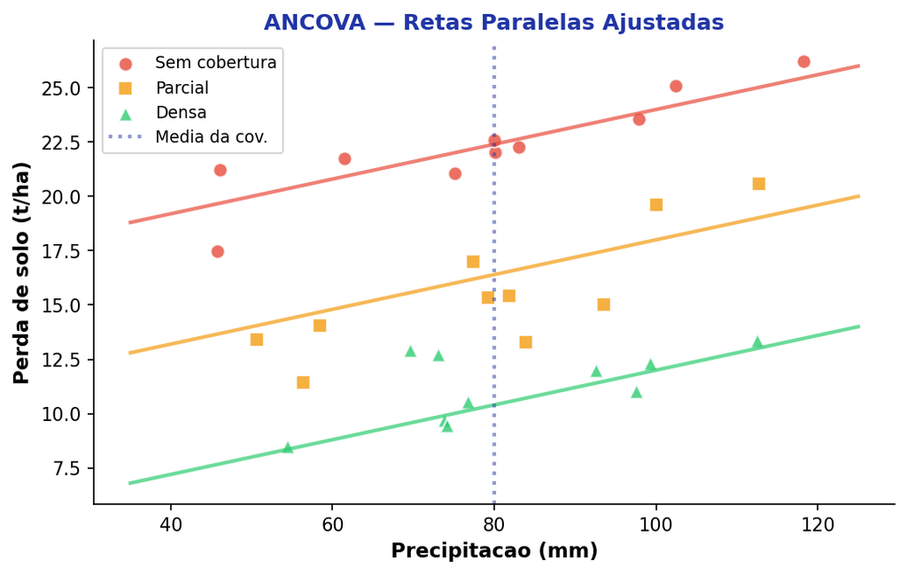

# 6 — ANCOVA vs. ANOVA

## Quando escolher cada técnica?

**Use ANOVA quando:**

- O delineamento controlou bem as variáveis de confusão
- Não há covariáveis contínuas relevantes
- Os grupos são balanceados e homogêneos

**Use ANCOVA quando:**

- Há variáveis contínuas que influenciam a VD
- Estudos de campo com variação ambiental
- Deseja aumentar o poder sem aumentar N
- Grupos diferem em uma variável de confusão

## Resumo — Fluxo de Decisão

```
flowchart LR
    A["Comparar médias\nentre grupos"]:::root --> B{"Há covariável\ncontínua?"}:::node
    B --> |"Não"| C["ANOVA"]:::leaf
    B --> |Sim| D{"Retas paralelas?\n(homogeneidade\nde inclinações)"}:::node
    D --> |Sim| E["ANCOVA"]:::result
    D --> |"Não"| F["Regressão com\ninteração\n(Johnson-Neyman)"]:::leaf
    E --> G["Comparar médias\najustadas\n(EMMs + post-hoc)"]:::result

    classDef root fill:#2135A6,color:#fff,font-weight:bold,stroke:#27368C
    classDef node fill:#C5CEE8,color:#0D0D0D,stroke:#586BA6
    classDef leaf fill:#586BA6,color:#fff,stroke:#27368C
    classDef result fill:#27368C,color:#fff,font-weight:bold,stroke:#2135A6
```

Obrigado!

Luiz Diego Vidal Santos

Universidade Estadual de Feira de Santana (UEFS)